# Badanie zmienności rozkładu średniej arytmetycznej

Olga Sieradzan, Aleksandra Węgrzyn

2023-12-21

W badaniu rozważamy **rozkład Poissona** z 𝜆 = 1 i 𝜆 = 40.

# Wariant pierwszy

## 0. Podstawowe charakterystyki rozkładu Poissona

**Rozkład Poissona** jest rozkładem dyskretnym o zbiorze wartości X = {0, 1, 2, …}.

Zmienna losowa X ma rozkład Poissona z parametrem 𝜆 > 0 jeżeli jej funkcja prawdopodobieństwa opisana jest wzorem:

**P (X = k) = $\frac{𝜆^{k}}{k!}$ $e^{-𝜆}$** dla k = 0, 1, 2, …

Ponadto rozkład Poissona posiada własności:

- **E(X) = λ**
- **Var(X) = λ**

Chcąc wyznaczyć podstawowe charakterystyki rozkładu Poissona z parametrami λ = 1 oraz λ = 40, generujemy 300 danych pochodzących z tego rozkładu. Wartości statystyk zamieszczamy w poniższych tabelach:

*Tabela 1.1. Podstawowe statystyki rozkładu Poissona z parametrem λ = 1*

| średnia | odch_stand | skośność | kurtoza |
| --- | --- | --- | --- |
| 0.9033333 | 0.907414 | 0.9714763 | 3.776176 |

*Tabela 1.2. Podstawowe statystyki rozkładu Poissona z parametrem λ = 40*

| średnia | odch_stand | skośność | kurtoza |
| --- | --- | --- | --- |
| 39.49333 | 6.389526 | 0.2352177 | 3.428782 |

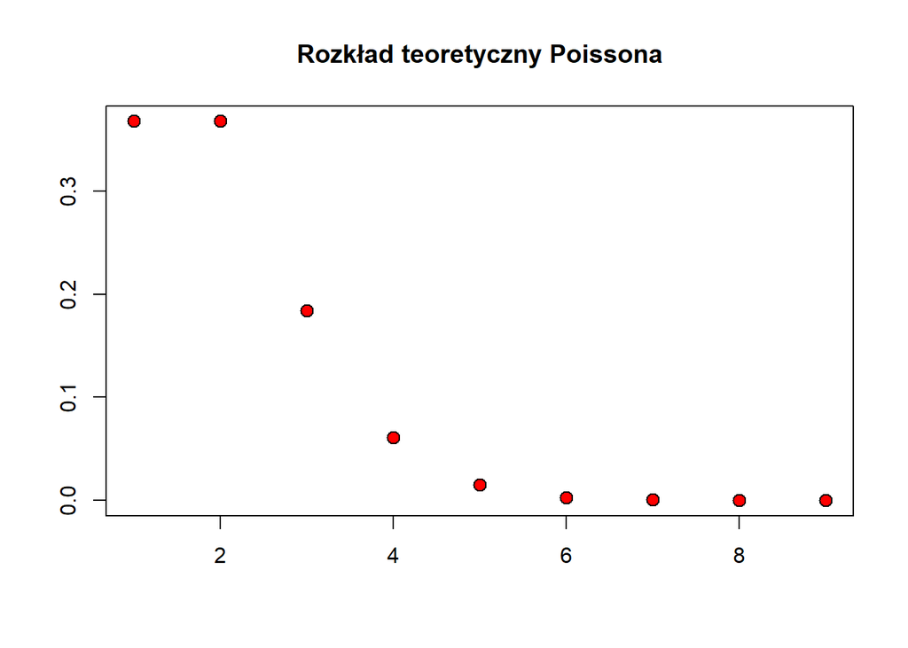

## 1-3. Wygenerowanie danych i wyliczenie średniej arytmetycznej

Zamiast N = 300, postanowiłyśmy zamienić je na N = 800.

*Tabela 1.3. Zestawienie wyznaczonych wartości w zależności od k* *dla danych z rozkładu Poissona z parametrem λ = 1*

|  | V2 | V3 | V4 | V5 | V6 | V7 | V8 | V9 | V10 | V11 | V12 | V13 | V14 | V15 | V16 | V17 | V18 | V19 | V20 | V21 | V22 | V23 | V24 | V25 | V26 | V27 | V28 | V29 | V30 | … |
| --- | --- | --- | --- | --- | --- | --- | --- | --- | --- | --- | --- | --- | --- | --- | --- | --- | --- | --- | --- | --- | --- | --- | --- | --- | --- | --- | --- | --- | --- | --- |
| 5 | 0.8000000 | 1.800000 | 0.800 | 1.000000 | 0.8000000 | 0.4000000 | 2.000 | 0.6000000 | 1.8000000 | 0.8000000 | 1.000 | 1.200 | 1.4000000 | 1.0000000 | 0.800 | 1.600 | 1.0000000 | 1.000 | 1.000000 | 1.000000 | 1.600000 | 0.600000 | 1.200 | 2.000000 | 1.200 | 1.0000000 | 0.4000000 | 0.800 | 1.0000000 | … |
| 10 | 1.1000000 | 1.400000 | 0.900 | 0.400000 | 0.6000000 | 0.9000000 | 0.700 | 1.0000000 | 0.8000000 | 1.3000000 | 0.800 | 1.100 | 0.7000000 | 0.6000000 | 1.100 | 1.100 | 0.7000000 | 0.800 | 1.200000 | 1.200000 | 1.100000 | 0.700000 | 1.000 | 1.100000 | 1.300 | 1.0000000 | 1.2000000 | 0.700 | 0.5000000 | … |
| 20 | 0.9500000 | 1.200000 | 0.900 | 1.000000 | 0.8500000 | 1.1000000 | 1.250 | 1.1500000 | 1.1000000 | 0.7500000 | 1.100 | 1.100 | 1.0000000 | 0.8000000 | 0.900 | 1.050 | 0.6500000 | 0.650 | 1.500000 | 1.100000 | 0.950000 | 0.850000 | 1.000 | 0.800000 | 1.000 | 1.1500000 | 0.9500000 | 0.700 | 1.0500000 | … |
| 30 | 0.7333333 | 1.033333 | 1.300 | 1.166667 | 0.6333333 | 0.8333333 | 0.700 | 0.8333333 | 0.7666667 | 0.9333333 | 1.400 | 1.000 | 0.8666667 | 0.7333333 | 0.700 | 1.300 | 0.9333333 | 1.000 | 1.133333 | 1.133333 | 1.066667 | 1.433333 | 0.900 | 1.166667 | 1.400 | 0.7333333 | 0.9333333 | 1.100 | 0.9666667 | … |
| 50 | 0.9800000 | 0.960000 | 1.200 | 0.940000 | 0.8000000 | 1.2400000 | 0.880 | 0.8600000 | 1.2400000 | 0.8800000 | 0.880 | 1.020 | 1.0200000 | 0.7800000 | 1.120 | 1.140 | 0.9600000 | 1.040 | 0.900000 | 1.220000 | 0.960000 | 0.980000 | 1.040 | 1.040000 | 0.960 | 0.9000000 | 1.1400000 | 1.140 | 1.1200000 | … |
| 100 | 0.9700000 | 1.140000 | 0.950 | 0.880000 | 1.1500000 | 0.9600000 | 0.930 | 0.9800000 | 1.0700000 | 1.0000000 | 1.120 | 0.850 | 1.0500000 | 0.9200000 | 0.910 | 1.060 | 1.1000000 | 0.820 | 0.990000 | 1.030000 | 1.030000 | 0.990000 | 1.040 | 1.040000 | 1.070 | 0.8100000 | 1.0500000 | 1.040 | 1.3800000 | … |
| 200 | 1.0000000 | 1.015000 | 1.105 | 1.135000 | 0.9300000 | 1.0050000 | 0.945 | 1.0450000 | 0.9750000 | 1.0500000 | 1.070 | 0.935 | 0.9550000 | 0.9850000 | 1.060 | 1.015 | 0.9850000 | 0.980 | 1.085000 | 1.115000 | 1.030000 | 1.080000 | 1.050 | 0.955000 | 0.955 | 1.0700000 | 1.0650000 | 0.955 | 1.1100000 | … |
| 500 | 0.9880000 | 1.054000 | 0.988 | 1.010000 | 0.9960000 | 0.9380000 | 1.004 | 0.9800000 | 1.0200000 | 1.0140000 | 1.100 | 1.106 | 1.0280000 | 0.9800000 | 1.124 | 0.942 | 0.9840000 | 1.100 | 0.956000 | 1.022000 | 1.056000 | 0.970000 | 0.946 | 1.036000 | 0.956 | 1.0140000 | 1.0620000 | 0.892 | 1.0200000 | … |
| 1000 | 0.9880000 | 0.960000 | 0.998 | 1.051000 | 0.9870000 | 0.9940000 | 0.981 | 0.9920000 | 1.0310000 | 1.0130000 | 0.996 | 1.039 | 1.0200000 | 0.9820000 | 0.993 | 0.947 | 0.9700000 | 0.995 | 1.061000 | 1.009000 | 1.020000 | 1.043000 | 1.004 | 0.995000 | 1.024 | 0.9610000 | 0.9920000 | 0.976 | 1.0290000 | … |

*Tabela 1.4. Zestawienie wyznaczonych wartości w zależności od k* *dla danych z rozkładu Poissona z parametrem λ = 40*

| y | V2 | V3 | V4 | V5 | V6 | V7 | V8 | V9 | V10 | V11 | V12 | V13 | V14 | V15 | V16 | V17 | V18 | V19 | V20 | V21 | V22 | V23 | V24 | V25 | V26 | V27 | V28 | V29 | V30 | … |
| --- | --- | --- | --- | --- | --- | --- | --- | --- | --- | --- | --- | --- | --- | --- | --- | --- | --- | --- | --- | --- | --- | --- | --- | --- | --- | --- | --- | --- | --- | --- |
| 1 | 41.40000 | 34.600 | 46.400 | 40.60000 | 37.00000 | 40.20000 | 38.00 | 40.200 | 41.800 | 42.80000 | 40.00000 | 40.00000 | 36.800 | 38.80000 | 41.400 | 37.60000 | 36.00000 | 37.600 | 42.00000 | 36.800 | 43.200 | 45.20000 | 39.60000 | 41.200 | 36.400 | 42.20000 | 41.400 | 39.60000 | 38.600 | … |
| 2 | 40.20000 | 38.300 | 41.700 | 39.50000 | 43.50000 | 40.10000 | 41.80 | 41.700 | 39.800 | 40.80000 | 42.10000 | 37.50000 | 39.000 | 43.50000 | 42.300 | 37.90000 | 43.10000 | 37.700 | 40.20000 | 35.300 | 36.300 | 38.70000 | 39.80000 | 39.400 | 37.900 | 40.30000 | 36.300 | 39.10000 | 41.900 | … |
| 3 | 38.55000 | 41.350 | 39.300 | 41.95000 | 39.20000 | 42.15000 | 39.20 | 40.850 | 40.750 | 40.60000 | 37.65000 | 40.85000 | 39.600 | 42.40000 | 41.400 | 39.65000 | 38.35000 | 41.550 | 39.80000 | 40.100 | 38.350 | 39.85000 | 37.35000 | 40.550 | 40.150 | 40.90000 | 41.750 | 39.35000 | 39.750 | … |
| 4 | 40.66667 | 40.300 | 40.600 | 38.93333 | 40.46667 | 39.43333 | 42.40 | 39.200 | 41.100 | 41.46667 | 39.96667 | 39.83333 | 37.400 | 38.66667 | 40.800 | 41.16667 | 39.66667 | 41.800 | 39.93333 | 40.400 | 38.100 | 40.96667 | 41.73333 | 40.700 | 37.400 | 40.93333 | 39.900 | 39.83333 | 39.400 | … |
| 5 | 39.78000 | 40.420 | 40.680 | 40.06000 | 40.54000 | 39.88000 | 40.74 | 40.420 | 40.540 | 41.46000 | 39.58000 | 38.86000 | 39.560 | 39.40000 | 40.280 | 39.44000 | 40.06000 | 40.480 | 39.70000 | 41.160 | 39.820 | 39.08000 | 40.52000 | 40.680 | 40.940 | 41.18000 | 40.500 | 40.22000 | 38.800 | … |
| 6 | 39.92000 | 40.350 | 40.350 | 40.05000 | 39.70000 | 39.88000 | 40.04 | 39.620 | 40.230 | 40.64000 | 39.85000 | 40.18000 | 40.950 | 39.80000 | 39.940 | 40.06000 | 40.00000 | 41.530 | 39.92000 | 39.320 | 40.580 | 39.84000 | 39.21000 | 39.000 | 40.530 | 41.30000 | 39.970 | 40.35000 | 40.160 | … |
| 7 | 38.88000 | 39.910 | 40.505 | 40.94000 | 39.59500 | 40.34000 | 39.31 | 39.575 | 40.170 | 39.95500 | 39.60000 | 40.39000 | 40.535 | 39.43500 | 39.695 | 40.02000 | 39.41000 | 39.190 | 40.17500 | 40.340 | 41.120 | 39.82000 | 40.52500 | 39.840 | 39.530 | 39.84000 | 39.915 | 40.31000 | 39.920 | … |
| 8 | 40.13400 | 39.916 | 39.966 | 40.34200 | 40.10400 | 40.20200 | 40.23 | 40.560 | 40.398 | 40.31800 | 40.08000 | 39.82400 | 39.970 | 40.08000 | 39.240 | 39.90200 | 39.77400 | 39.868 | 40.12000 | 39.824 | 39.962 | 40.12000 | 40.06600 | 40.100 | 40.178 | 40.16000 | 39.426 | 40.06400 | 39.736 | … |
| 9 | 40.09300 | 40.062 | 39.804 | 40.05900 | 39.63400 | 39.80600 | 39.76 | 40.254 | 39.821 | 39.91900 | 40.19500 | 40.43200 | 39.987 | 40.45700 | 40.018 | 40.31100 | 40.18800 | 39.729 | 40.19400 | 39.895 | 40.201 | 39.96600 | 39.99300 | 39.868 | 39.737 | 39.99000 | 39.757 | 39.70400 | 39.877 | … |

## 4. Podstawowe charakterystyki zbioru obliczonych średnich arytmetycznych

### Średnia arytmetyczna

*Tabela 1.5. Zestawienie średnich arytmetycznych w zależności od k* *dla danych z rozkładu Poissona z parametrem λ = 1*

| 5 | 10 | 20 | 30 | 50 | 100 | 200 | 500 | 1000 |
| --- | --- | --- | --- | --- | --- | --- | --- | --- |
| 0.991 | 1.012 | 1.012 | 0.989 | 0.994 | 1.001 | 1.001 | 1.002 | 0.998 |

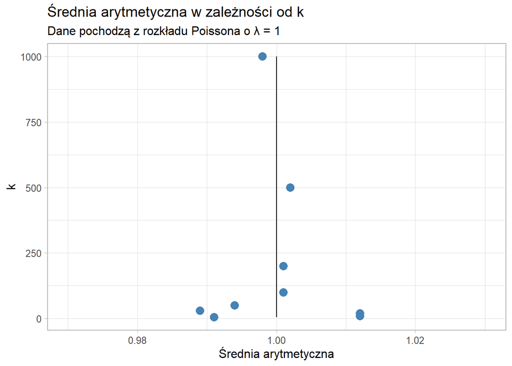

Czarna linia reprezentuje wartość oczekiwaną rozkładu.

Wartości średnich są zdecydowanie bardziej rozproszone dla małych k. Dla bardzo dużego k różnica jest minimalna. Wszystkie różnice są nie większe niż 0.07.

*Tabela 1.6. Zestawienie średnich arytmetycznych w zależności od k* *dla danych z rozkładu Poissona z parametrem λ = 40*

| 5 | 10 | 20 | 30 | 50 | 100 | 200 | 500 | 1000 |
| --- | --- | --- | --- | --- | --- | --- | --- | --- |
| 39.973 | 39.897 | 40.091 | 39.997 | 40 | 39.988 | 39.987 | 39.996 | 39.997 |

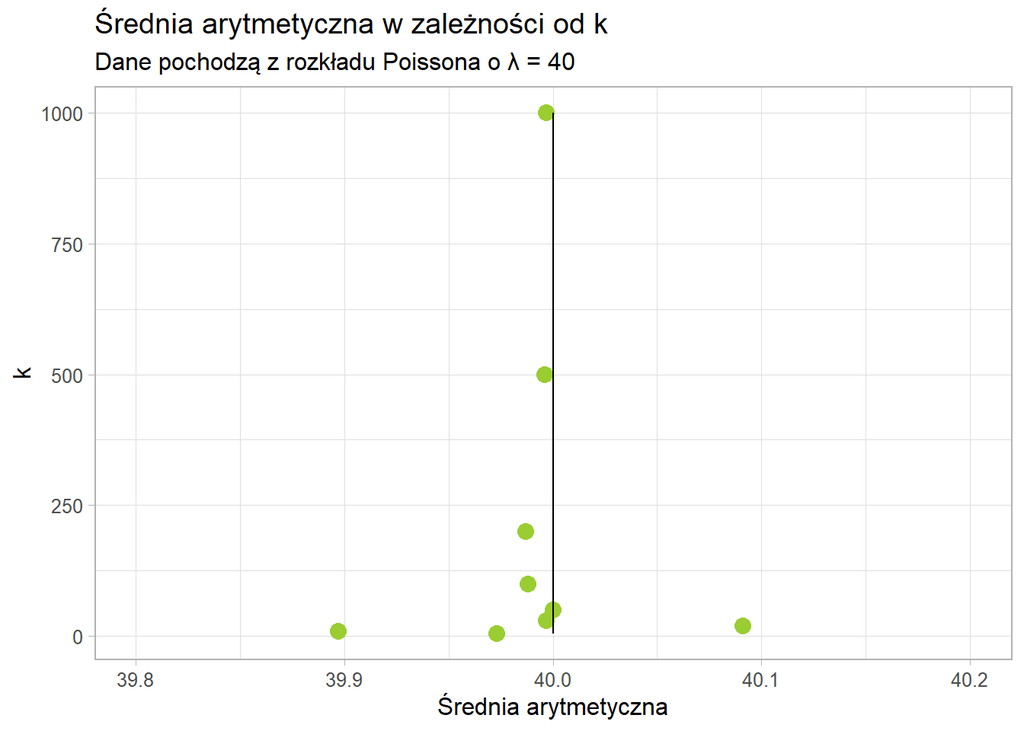

### Odchylenie standardowe

*Tabela 1.7. Zestawienie odchyleń standardowych w zależności od k* *dla danych z rozkładu Poissona z parametrem λ = 1*

| 5 | 10 | 20 | 30 | 50 | 100 | 200 | 500 | 1000 |
| --- | --- | --- | --- | --- | --- | --- | --- | --- |
| 0.441 | 0.311 | 0.22 | 0.181 | 0.139 | 0.101 | 0.07 | 0.045 | 0.032 |

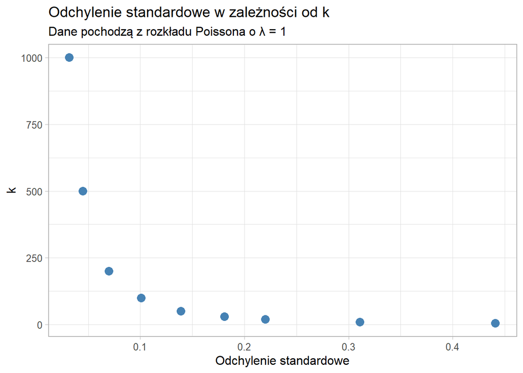

Wykres jednoznacznie wskazuje na drastyczny wzrost odchylenia standardowego wraz ze spadkiem k.

*Tabela 1.7. Zestawienie odchyleń standardowych w zależności od k* *dla danych z rozkładu Poissona z parametrem λ = 40*

| 5 | 10 | 20 | 30 | 50 | 100 | 200 | 500 | 1000 |
| --- | --- | --- | --- | --- | --- | --- | --- | --- |
| 2.776 | 1.959 | 1.454 | 1.15 | 0.87 | 0.619 | 0.44 | 0.286 | 0.193 |

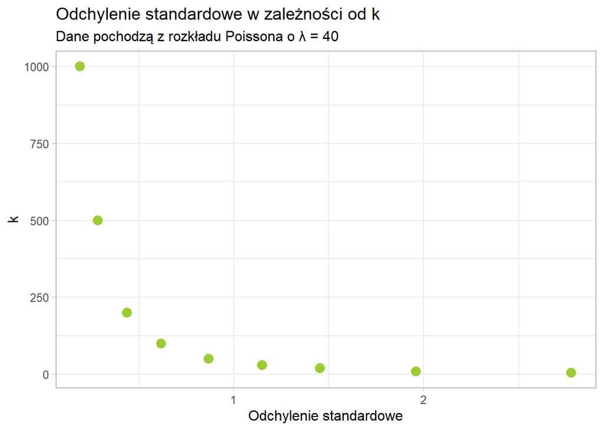

Ponownie pojawia sie ta zależność, tylko tym razem widać różnice między najniższymi odczytami odchylenia standardowego dla różnych lambd.

Dla lambda = 1, było to praktycznie 0, tutaj 0.2.

### Skośność

*Tabela 1.8. Zestawienie współczynników skośności w zależności od k* *dla danych z rozkładu Poissona z parametrem λ = 1*

| 5 | 10 | 20 | 30 | 50 | 100 | 200 | 500 | 1000 |
| --- | --- | --- | --- | --- | --- | --- | --- | --- |
| 0.536 | 0.244 | 0.126 | 0.244 | 0.198 | 0.191 | 0.167 | -0.009 | 0.103 |

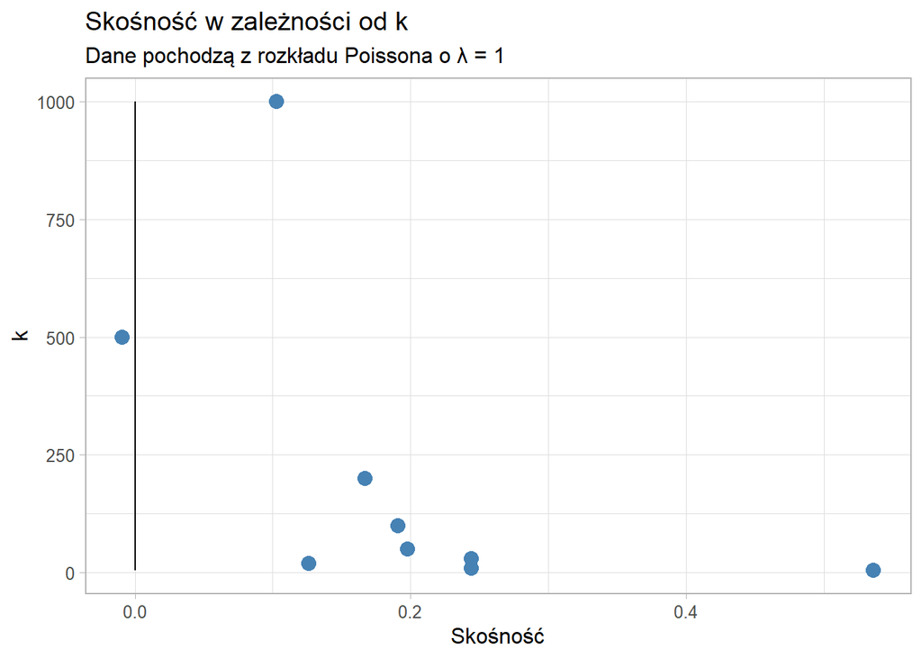

*Tabela 1.9. Zestawienie współczynników skośności w zależności od k* *dla danych z rozkładu Poissona z parametrem λ = 40*

| 5 | 10 | 20 | 30 | 50 | 100 | 200 | 500 | 1000 |
| --- | --- | --- | --- | --- | --- | --- | --- | --- |
| 0.121 | -0.034 | 0.12 | 0.187 | 0.162 | 0.073 | 0.059 | -0.068 | 0.058 |

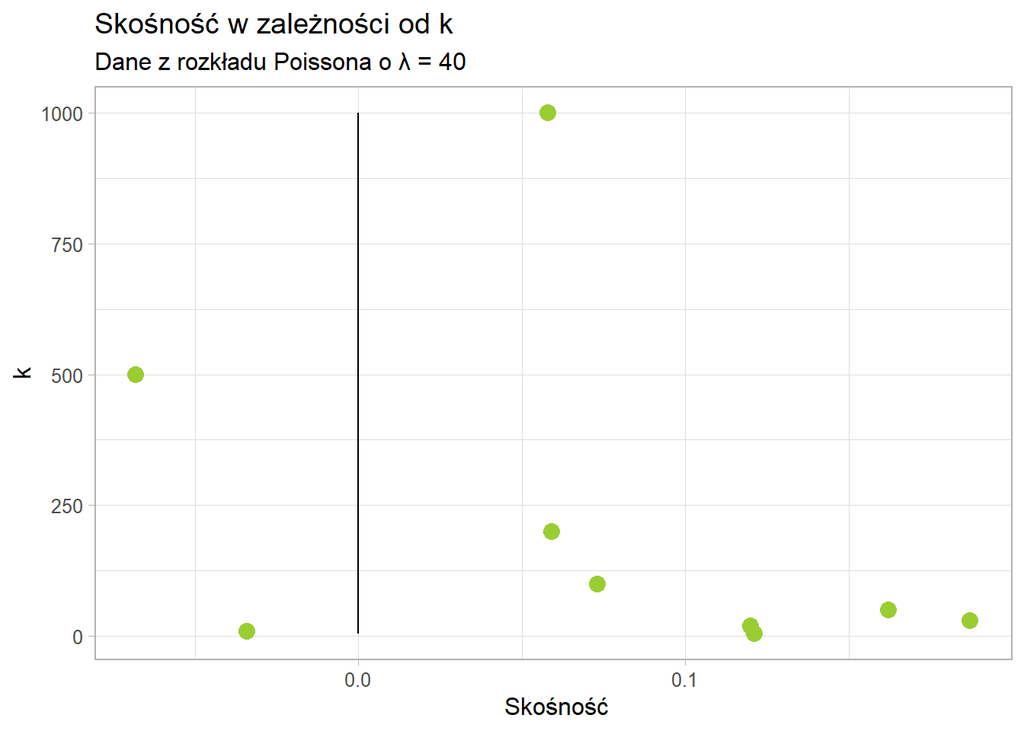

Dla λ = 40 sytuacja wygląda inaczej. Po pierwsze, skośności rozkładów są zdecydowanie mniejsze w porównaniu z poprzednim przypadkiem oraz wystepują ujemne wartości współczynnika asymetrii, czyli niektóre z tych rozkładów cechują się asymetrią lewostronną. Pozostaje jednak zależność im większe k, tym mniejsza skośność.

### Kurtoza

*Tabela 1.10. Zestawienie kurtozy w zależności od k* *dla danych z rozkładu Poissona z parametrem λ = 1*

| 5 | 10 | 20 | 30 | 50 | 100 | 200 | 500 | 1000 |
| --- | --- | --- | --- | --- | --- | --- | --- | --- |
| 3.342 | 3.058 | 2.997 | 3.187 | 3.034 | 3.269 | 3.396 | 3.332 | 3.103 |

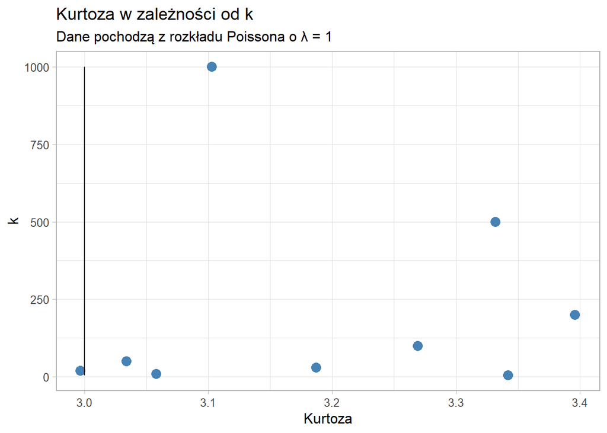

*Tabela 1.11. Zestawienie kurtozy w zależności od k* *dla danych z rozkładu Poissona z parametrem λ = 40*

| 5 | 10 | 20 | 30 | 50 | 100 | 200 | 500 | 1000 |
| --- | --- | --- | --- | --- | --- | --- | --- | --- |
| 2.91 | 2.838 | 3.125 | 2.902 | 2.772 | 2.809 | 2.756 | 2.889 | 3.092 |

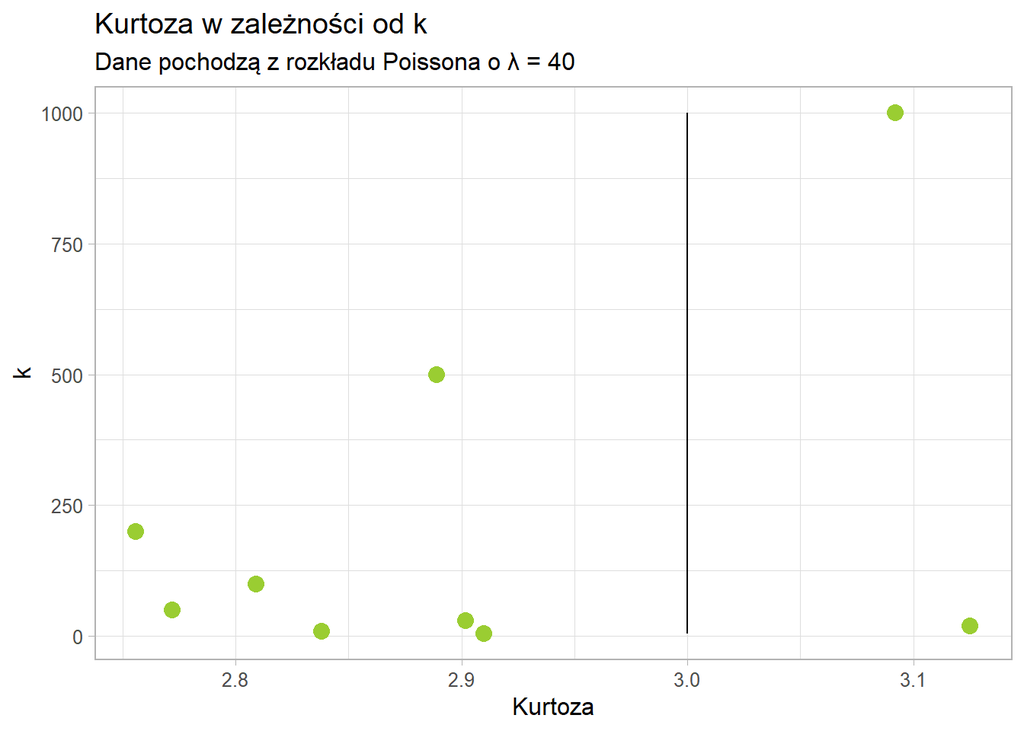

Skośność wyszła na tyle niska że można interpretować eksces. Występują zarówno rozkłady platokurtyczne i leptokurtyczne, chociaż różnica od 3 jest nieduża.

## 5.Wizualizacja danych

### Wykresy gęstości

*Zestawienie wykresów gęstości w zależności od k* *dla danych z rozkładu Poissona z parametrem λ = 1*

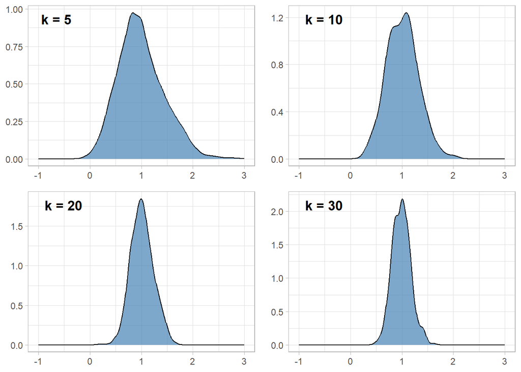

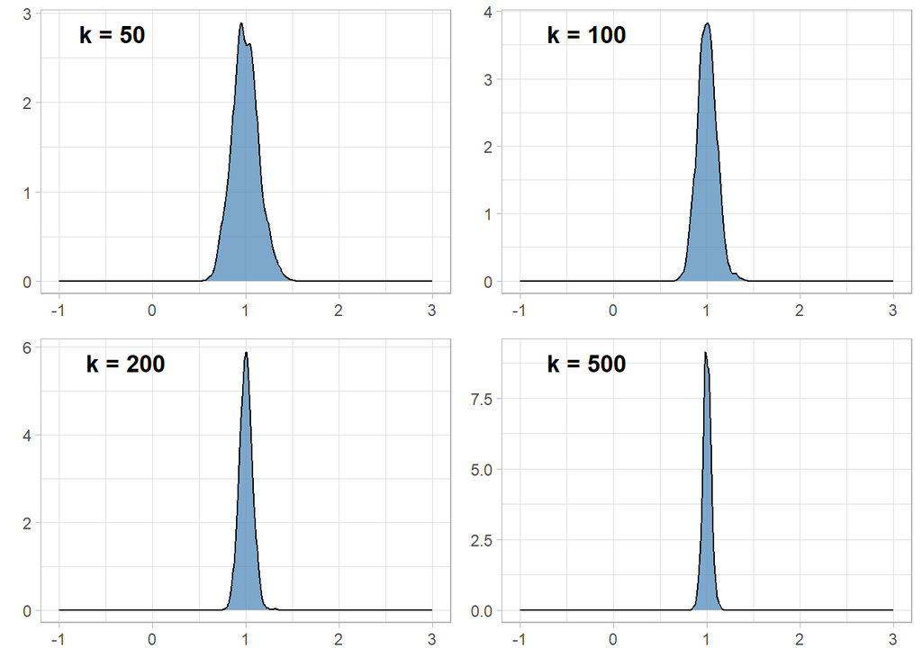

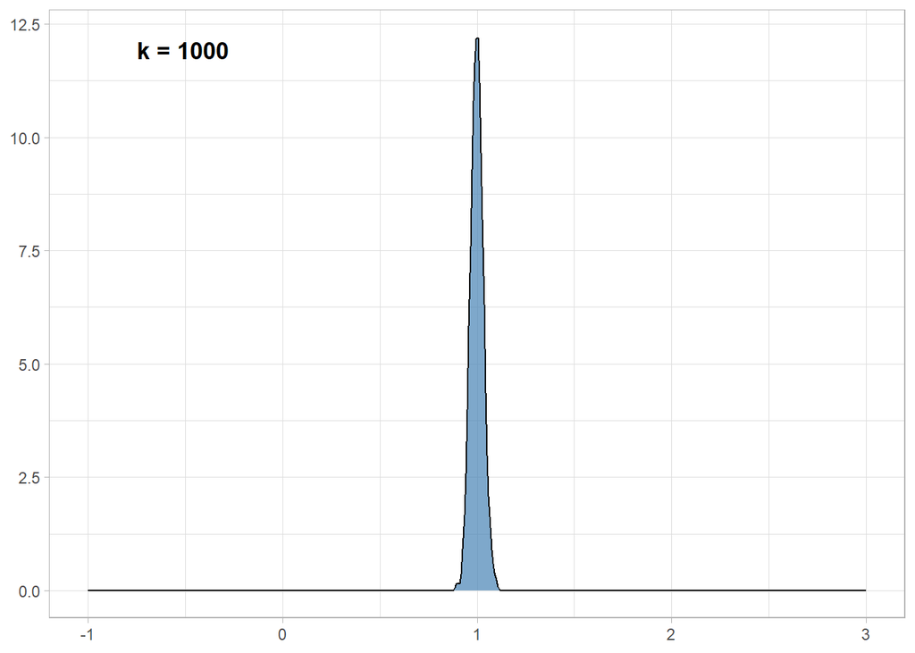

Na wykresach jednoznacznie widać zależność im większe k, tym bardziej wartości skupiają się wokół wartości oczekiwanej (której estymatorem jest parametr λ).

*Zestawienie wykresów gęstości w zależności od k* *dla danych z rozkładu Poissona z parametrem λ = 40*

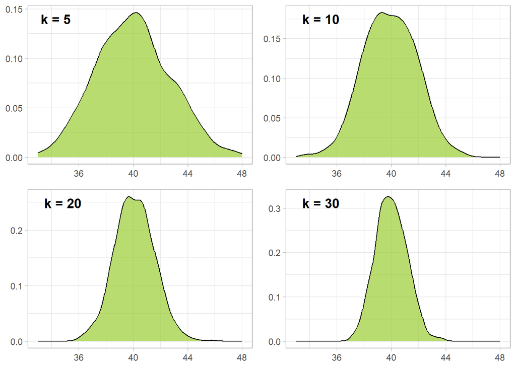

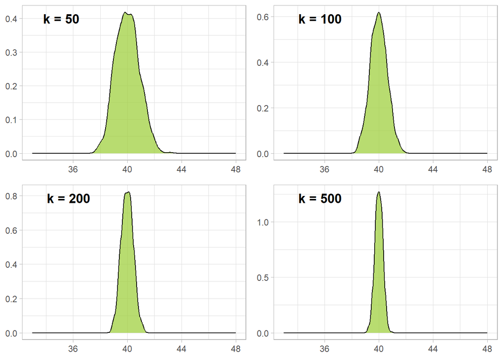

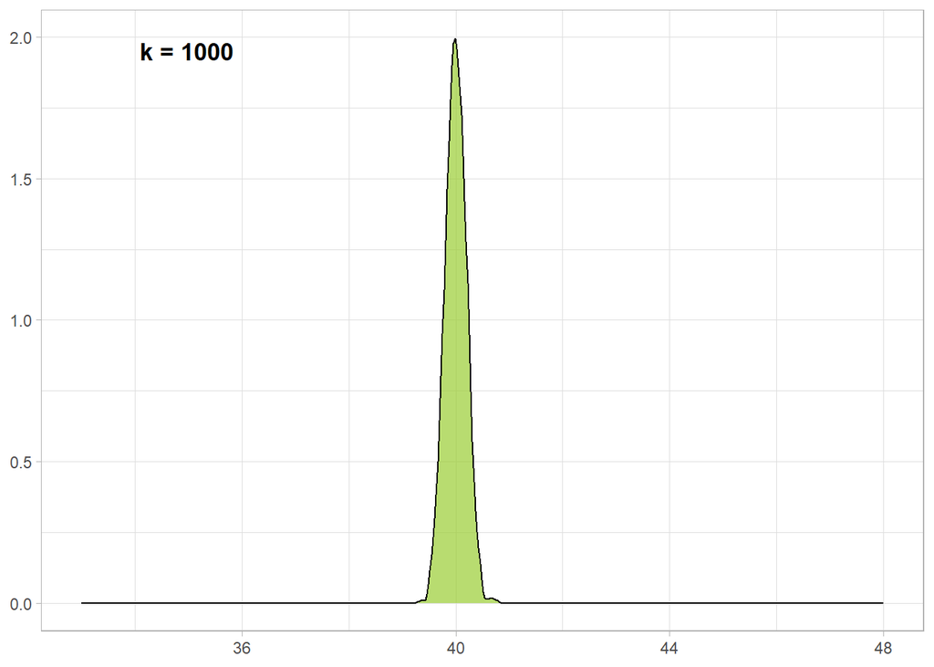

W tym przypadku występuje ta sama zależność, tylko że tym razem wartości na skali x mają większy rozstęp. Oznacza to, że im większa lambda, tym szerszy staje się rozkład w porównaniu z mniejszymi lambdami.

### Wykresy pudełkowe

*Zestawienie wykresów pudełkowych w zależności od k* *dla danych z rozkładu Poissona z parametrem λ = 1*

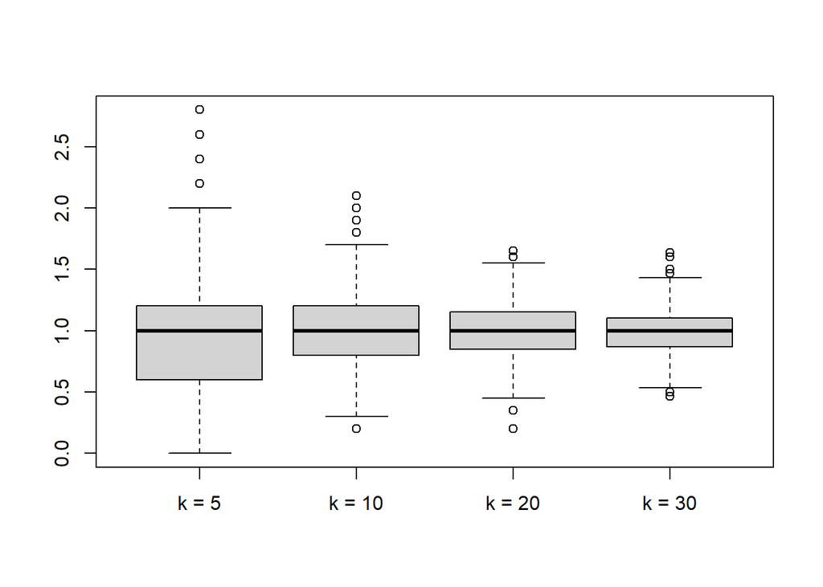

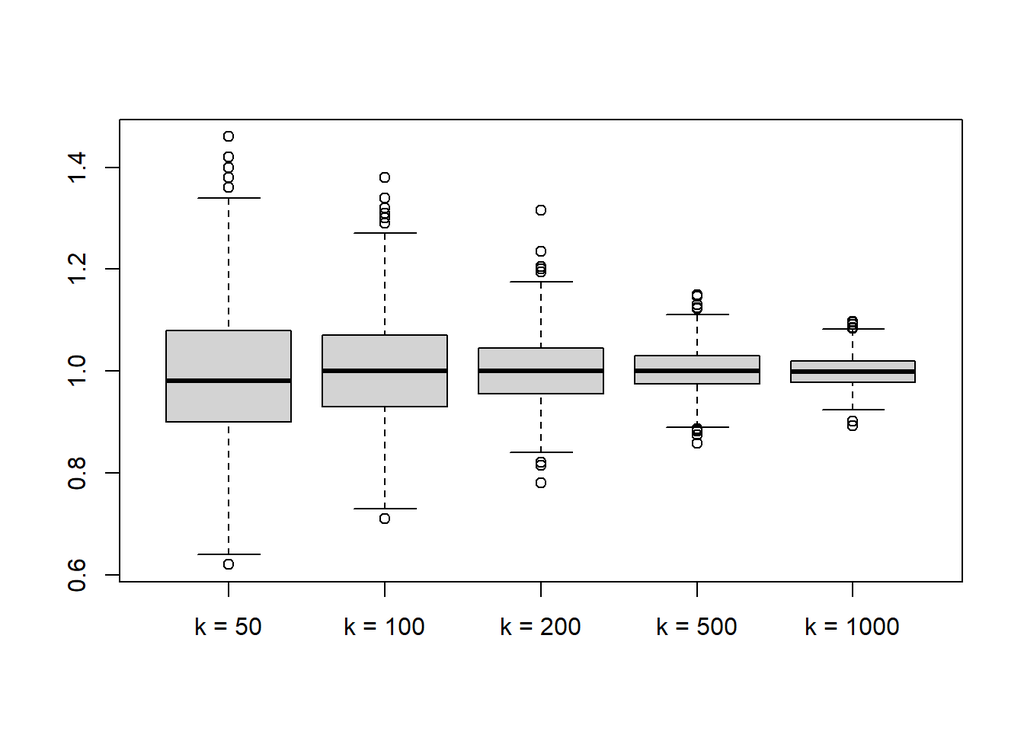

*Zestawienie wykresów pudełkowych w zależności od k* *dla danych z rozkładu Poissona z parametrem λ = 40*

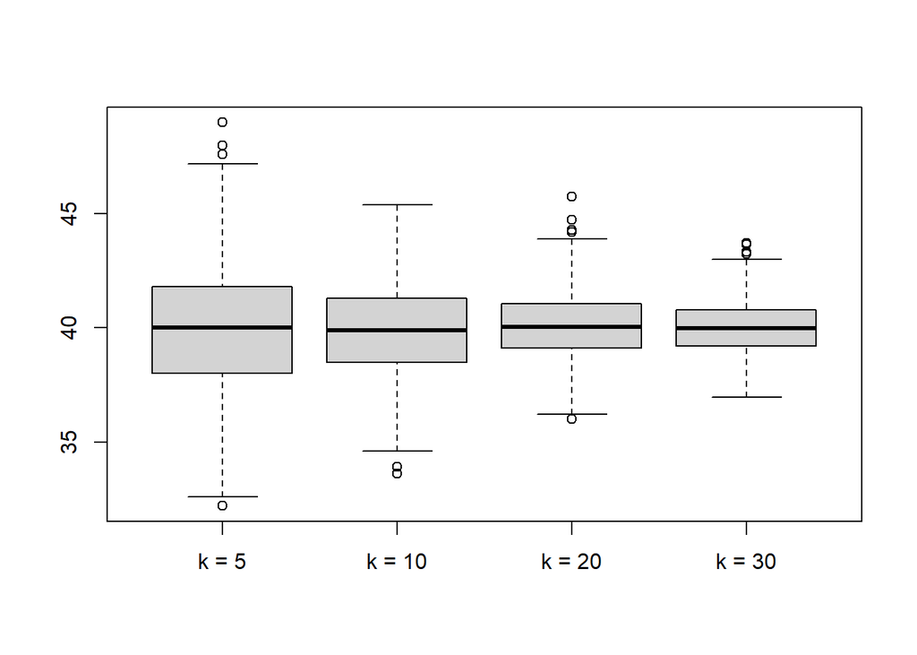

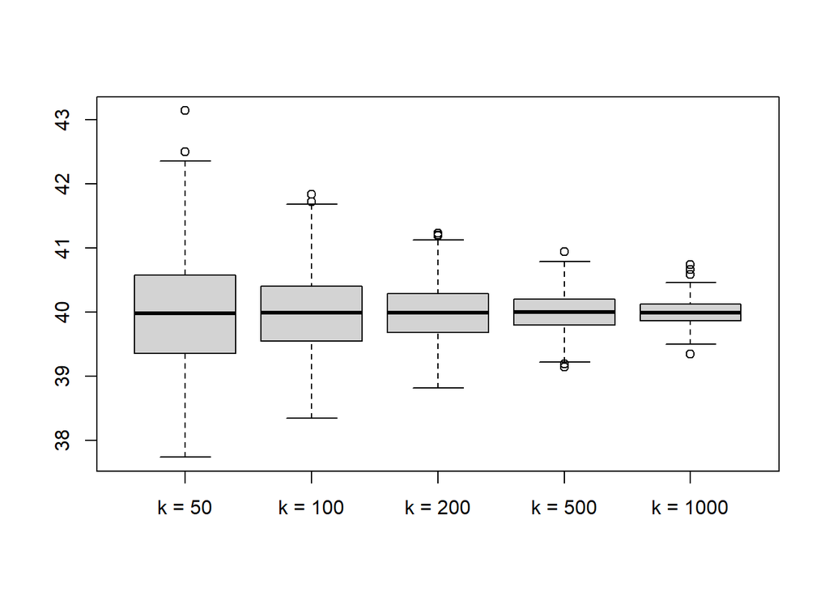

W tym przypadku różnica między najdalszymi wartościami odstającymi a wartością oczekiwaną jest równa 10, czyli jest 5 razy większa niż dla λ = 1.

## 6. Badanie normalności rozkładu - test Shapiro-Wilka

Za pomocą testu Shapiro - Wilka dokonamy weryfikacji hipotezy o normalności badanego przez nas rozkładu.

**Hipoteza 0: Badany rozkład jest normalny**

**Hipoteza 1: Badany rozkład nie jest normalny**

poziom istotności α = 0.1

*Tabela 1.12. Wartości p-value dla testu Shapiro-Wilka przeprowadzonego na* *rozkładzie Poissona z parametrem λ = 1, dla konkretnych k*

| 5 | 10 | 20 | 30 | 50 | 100 | 200 | 500 | 1000 |
| --- | --- | --- | --- | --- | --- | --- | --- | --- |
| 0 | 0 | 0 | 0 | 0.006 | 0.029 | 0.087 | 0.211 | 0.521 |

Wizualizacja wyników dla parametru λ = 1.

Czarna linia na wykresie reprezentuje poziom istotności α.

Dla wszystkich przypadków jakie wychodzą ponad linię, nie ma podstaw do odrzucenia H0.

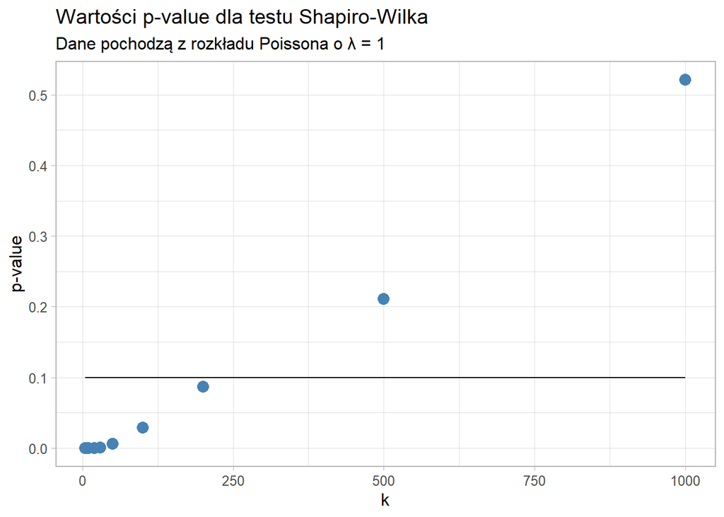

*Tabela 1.13. Wartości p-value dla testu Shapiro-Wilka przeprowadzonego na* *rozkładzie Poissona z parametrem λ = 40, dla konkretnych k*

| 5 | 10 | 20 | 30 | 50 | 100 | 200 | 500 | 1000 |
| --- | --- | --- | --- | --- | --- | --- | --- | --- |
| 0.295 | 0.412 | 0.515 | 0.067 | 0.041 | 0.377 | 0.362 | 0.747 | 0.646 |

Wizualizacja wyników dla λ = 40.

W tym przypadku tylko dla k = 30 oraz k = 50, mamy podstawy do odrzucenia H0, przy czym dla mniejszego k = 5 nie możemy odrzucić H0.

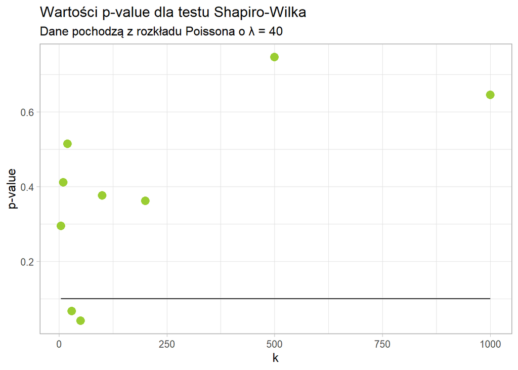

***

### Podsumowanie

W poniższych tabelach zamieszczone zostały zestawienia podstawowych charakterystyk rozkładu w zależności od liczby danych wykorzystanych do obliczenia średniej (k).

*Tabela 1.14. Zestawienie podstawowych statystyk w zależności od k* *dla danych z rozkładu Poissona z parametrem λ = 1*

|  | 5 | 10 | 20 | 30 | 50 | 100 | 200 | 500 | 1000 |
| --- | --- | --- | --- | --- | --- | --- | --- | --- | --- |
| średnia | 0.991 | 1.012 | 1.012 | 0.989 | 0.994 | 1.001 | 1.001 | 1.002 | 0.998 |
| odch_stand | 0.441 | 0.311 | 0.220 | 0.181 | 0.139 | 0.101 | 0.070 | 0.045 | 0.032 |
| skośność | 0.536 | 0.244 | 0.126 | 0.244 | 0.198 | 0.191 | 0.167 | -0.009 | 0.103 |
| kurtoza | 3.342 | 3.058 | 2.997 | 3.187 | 3.034 | 3.269 | 3.396 | 3.332 | 3.103 |

*Tabela 1.15. Zestawienie podstawowych statystyk w zależności od k* *dla danych z rozkładu Poissona z parametrem λ = 40*

|  | 5 | 10 | 20 | 30 | 50 | 100 | 200 | 500 | 1000 |
| --- | --- | --- | --- | --- | --- | --- | --- | --- | --- |
| średnia | 39.973 | 39.897 | 40.091 | 39.997 | 40.000 | 39.988 | 39.987 | 39.996 | 39.997 |
| odch_stand | 2.776 | 1.959 | 1.454 | 1.150 | 0.870 | 0.619 | 0.440 | 0.286 | 0.193 |
| skośność | 0.121 | -0.034 | 0.120 | 0.187 | 0.162 | 0.073 | 0.059 | -0.068 | 0.058 |
| kurtoza | 2.910 | 2.838 | 3.125 | 2.902 | 2.772 | 2.809 | 2.756 | 2.889 | 3.092 |

Wnioski:

- nie występuje zależność między liczbą danych a średnią arytmetyczną - wartości średnich arytmetycznych są bliskie wartości parametru $λ=1$ oraz $λ=40$
- występuje widoczna zależność między liczbą danych a odchyleniem standardowym: wraz ze wzrostem liczby danych, odchylenie standardowe maleje Oznacza to, że większa liczba danych powoduje mniejszą zmienność
- występują dodatnie oraz ujemne wartości skośności rozkładu - co wskazuje odpowiednio na asymetrię prawostronną oraz lewostronną; pojawia się tu zależność: im większa wartość k, tym mniejsza skośność rozkładu
- wartości kurtozy są mniejsze oraz większe od 3, co wskazuje na występowanie zarówno rozkładów platokurtycznych, jak i leptokurtycznych

# Wariant drugi

## 0. Podstawowe charakterystyki rozkładu Poissona

*Tabela 2.1. Podstawowe statystyki dla danych z rozkładu Poissona z parametrem λ = 1 podniesione do kwadratu*

| średnia | odch_stand | skośność | kurtoza |
| --- | --- | --- | --- |
| 1.736667 | 3.123006 | 4.185638 | 26.20479 |

*Tabela 2.2. Podstawowe statystyki dla danych z rozkładu Poissona z parametrem λ = 40 podniesione do kwadratu*

| średnia | odch_stand | skośność | kurtoza |
| --- | --- | --- | --- |
| 1610.2 | 513.8631 | 0.9101908 | 4.552648 |

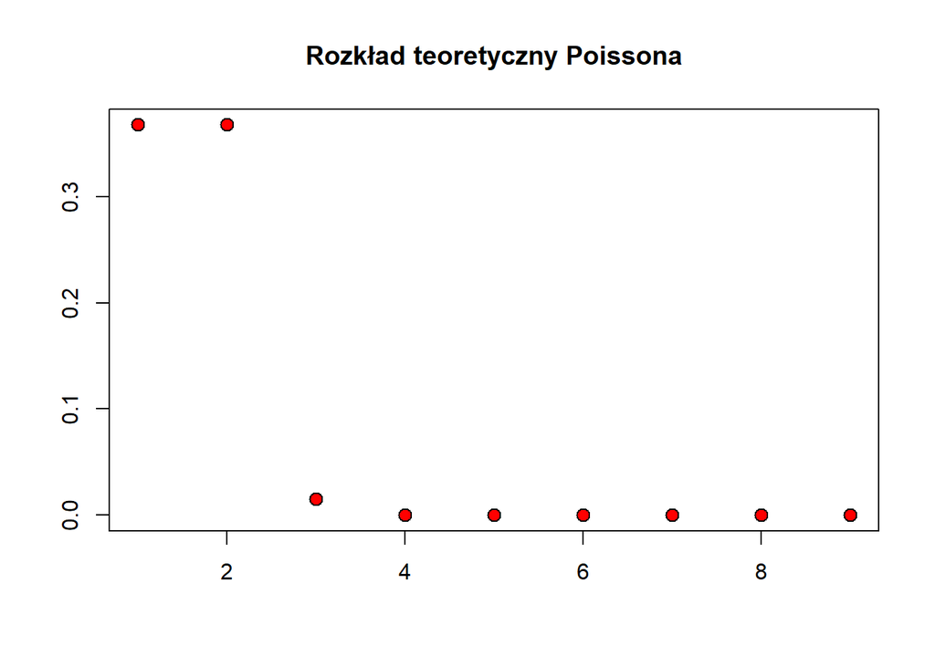

## 1-3. Wygenerowanie danych i wyliczenie średniej arytmetycznej

Zamiast N = 300, postanowiłyśmy zamienić je na N = 800.

Wylosowałyśmy dane z rozkładu Poissona z parametrami odpowiednio *λ = 1* oraz *λ = 40*, które nastepnie zostały poniesione do kwadratu. W poniższych tabelach umieściłyśmy wyliczone średnie arytmetyczne tych danych dla konkretnych k.

*Tabela 2.3. Zestawienie wyznaczonych wartości w zależności od k* *dla danych z rozkładu Poissona z parametrem λ = 1 podniesionych do kwadratu*

|  | V2 | V3 | V4 | V5 | V6 | V7 | V8 | V9 | V10 | V11 | V12 | V13 | V14 | V15 | V16 | V17 | V18 | V19 | V20 | V21 | V22 | V23 | V24 | V25 | V26 | V27 | V28 | V29 | V30 | … |
| --- | --- | --- | --- | --- | --- | --- | --- | --- | --- | --- | --- | --- | --- | --- | --- | --- | --- | --- | --- | --- | --- | --- | --- | --- | --- | --- | --- | --- | --- | --- |
| 5 | 2.000 | 1.800 | 0.200000 | 0.400 | 2.400000 | 3.400000 | 2.6000000 | 4.000000 | 0.200000 | 0.800000 | 0.600000 | 1.200000 | 0.800000 | 3.600000 | 1.400 | 2.000 | 5.600000 | 3.000000 | 1.000 | 1.000000 | 2.800 | 1.200000 | 1.000000 | 1.200 | 0.200000 | 2.800000 | 1.200 | 1.400 | 3.600000 | … |
| 10 | 2.800 | 2.900 | 4.500000 | 2.000 | 2.300000 | 1.600000 | 1.7000000 | 2.000000 | 1.000000 | 2.700000 | 1.400000 | 1.600000 | 1.600000 | 0.500000 | 3.700 | 2.400 | 5.700000 | 3.000000 | 1.300 | 1.300000 | 2.000 | 3.600000 | 1.500000 | 4.700 | 1.300000 | 4.600000 | 1.000 | 1.400 | 1.400000 | … |
| 20 | 1.400 | 2.400 | 2.500000 | 1.650 | 2.550000 | 2.000000 | 3.7500000 | 0.700000 | 1.550000 | 1.300000 | 2.100000 | 1.850000 | 0.700000 | 1.300000 | 2.650 | 3.900 | 3.000000 | 2.400000 | 2.050 | 1.100000 | 2.550 | 2.650000 | 2.700000 | 1.600 | 1.750000 | 0.900000 | 2.350 | 1.800 | 1.550000 | … |
| 30 | 3.300 | 2.400 | 1.366667 | 2.300 | 1.433333 | 1.666667 | 0.8666667 | 3.166667 | 1.466667 | 2.166667 | 1.966667 | 2.266667 | 2.133333 | 2.433333 | 1.600 | 3.500 | 1.833333 | 1.433333 | 3.500 | 2.033333 | 1.200 | 2.666667 | 1.666667 | 2.300 | 2.533333 | 1.966667 | 2.300 | 1.600 | 3.133333 | … |
| 50 | 2.460 | 1.760 | 2.820000 | 2.600 | 1.540000 | 1.660000 | 1.5200000 | 2.460000 | 2.140000 | 1.740000 | 1.920000 | 1.800000 | 1.560000 | 1.340000 | 1.000 | 1.300 | 2.140000 | 3.300000 | 2.520 | 3.080000 | 2.600 | 1.460000 | 1.200000 | 1.820 | 1.700000 | 2.520000 | 1.960 | 1.640 | 3.300000 | … |
| 100 | 1.410 | 2.320 | 1.860000 | 1.930 | 2.170000 | 1.730000 | 1.9800000 | 1.910000 | 1.570000 | 2.420000 | 1.950000 | 2.100000 | 1.540000 | 2.360000 | 1.550 | 1.970 | 2.330000 | 1.490000 | 2.500 | 2.470000 | 2.340 | 2.330000 | 2.150000 | 1.600 | 2.330000 | 1.530000 | 1.690 | 2.250 | 1.990000 | … |
| 200 | 1.995 | 2.085 | 2.035000 | 2.450 | 2.185000 | 1.755000 | 2.2500000 | 1.990000 | 1.810000 | 1.970000 | 1.835000 | 1.710000 | 1.875000 | 1.945000 | 1.905 | 1.960 | 1.865000 | 2.330000 | 2.040 | 2.425000 | 1.950 | 2.230000 | 1.890000 | 1.650 | 2.070000 | 2.060000 | 1.995 | 2.320 | 1.970000 | … |
| 500 | 2.284 | 1.986 | 1.902000 | 1.874 | 1.816000 | 1.982000 | 1.9500000 | 2.070000 | 1.900000 | 2.064000 | 1.822000 | 2.014000 | 2.132000 | 2.136000 | 1.966 | 2.066 | 1.964000 | 2.012000 | 2.102 | 1.778000 | 2.266 | 1.862000 | 1.976000 | 2.032 | 2.086000 | 2.042000 | 1.870 | 1.948 | 2.072000 | … |
| 1000 | 1.996 | 1.916 | 1.953000 | 2.032 | 1.904000 | 2.052000 | 2.0330000 | 2.082000 | 1.840000 | 2.000000 | 1.791000 | 2.003000 | 1.924000 | 1.930000 | 2.087 | 2.047 | 2.038000 | 2.014000 | 1.869 | 1.778000 | 2.062 | 2.022000 | 1.940000 | 1.948 | 2.100000 | 1.746000 | 1.960 | 1.794 | 1.953000 | … |

*Tabela 2.4. Zestawienie wyznaczonych wartości w zależności od k* *dla danych z rozkładu Poissona z parametrem λ = 40 podniesionych do kwadratu*

|  | V2 | V3 | V4 | V5 | V6 | V7 | V8 | V9 | V10 | V11 | V12 | V13 | V14 | V15 | V16 | V17 | V18 | V19 | V20 | V21 | V22 | V23 | V24 | V25 | V26 | V27 | V28 | V29 | V30 | … |
| --- | --- | --- | --- | --- | --- | --- | --- | --- | --- | --- | --- | --- | --- | --- | --- | --- | --- | --- | --- | --- | --- | --- | --- | --- | --- | --- | --- | --- | --- | --- |
| 5 | 1411.000 | 1305.200 | 1729.400 | 1563.200 | 1462.000 | 1328.800 | 1568.200 | 1659.000 | 1767.200 | 1497.000 | 1253.000 | 1137.200 | 1657.400 | 1672.400 | 1552.800 | 1679.000 | 1465.200 | 1538.800 | 1948.000 | 1761.200 | 1438.200 | 1592.000 | 1201.400 | 1594.800 | 1579.000 | 1362.000 | 1749.600 | 2155.000 | 1853.000 | … |
| 10 | 1889.200 | 1771.100 | 1652.200 | 1696.100 | 2166.800 | 1632.400 | 1572.100 | 1853.500 | 1656.200 | 1807.600 | 1347.000 | 1597.000 | 1460.800 | 1978.900 | 1568.400 | 1652.500 | 1645.900 | 1646.200 | 1383.800 | 1522.500 | 1719.600 | 1692.600 | 1610.400 | 1782.400 | 1696.500 | 1220.500 | 1945.700 | 1347.300 | 1751.900 | … |
| 20 | 1957.850 | 1549.600 | 1625.800 | 1609.550 | 1491.100 | 1517.350 | 1740.750 | 1590.700 | 1599.500 | 1796.300 | 1727.950 | 1498.650 | 1640.500 | 1620.100 | 1636.850 | 1710.100 | 1491.500 | 1634.100 | 1592.100 | 1423.100 | 1813.400 | 1700.300 | 1627.050 | 1588.550 | 1677.050 | 1379.600 | 1577.450 | 1633.550 | 1499.500 | … |
| 30 | 1524.800 | 1609.467 | 1568.933 | 1542.767 | 1699.200 | 1666.900 | 1575.000 | 1741.733 | 1695.433 | 1558.133 | 1574.100 | 1656.733 | 1694.467 | 1606.867 | 1485.100 | 1690.000 | 1532.400 | 1746.367 | 1658.400 | 1663.333 | 1736.900 | 1658.100 | 1470.367 | 1715.567 | 1655.867 | 1610.100 | 1724.167 | 1559.167 | 1615.033 | … |
| 50 | 1621.600 | 1533.180 | 1575.420 | 1761.900 | 1796.980 | 1569.780 | 1545.080 | 1536.180 | 1648.500 | 1790.040 | 1582.420 | 1572.520 | 1638.340 | 1640.260 | 1605.780 | 1589.800 | 1659.860 | 1480.760 | 1789.560 | 1560.860 | 1517.140 | 1689.560 | 1425.760 | 1630.580 | 1642.740 | 1557.160 | 1632.100 | 1712.760 | 1621.140 | … |
| 100 | 1608.410 | 1649.790 | 1604.190 | 1543.950 | 1624.340 | 1546.150 | 1624.290 | 1579.050 | 1733.680 | 1583.920 | 1623.330 | 1615.710 | 1662.870 | 1724.810 | 1561.120 | 1643.880 | 1616.630 | 1639.100 | 1619.170 | 1550.990 | 1615.740 | 1581.910 | 1657.710 | 1665.090 | 1727.800 | 1606.490 | 1709.010 | 1611.970 | 1602.350 | … |
| 200 | 1610.380 | 1591.575 | 1631.685 | 1701.535 | 1643.170 | 1699.430 | 1661.955 | 1678.815 | 1623.640 | 1680.495 | 1632.360 | 1550.320 | 1625.880 | 1650.315 | 1571.520 | 1651.615 | 1668.740 | 1652.410 | 1644.950 | 1644.765 | 1664.215 | 1641.275 | 1669.565 | 1674.150 | 1623.645 | 1629.800 | 1669.590 | 1676.245 | 1607.235 | … |
| 500 | 1639.596 | 1635.142 | 1575.862 | 1651.322 | 1651.650 | 1588.426 | 1608.270 | 1606.244 | 1645.130 | 1633.096 | 1590.358 | 1666.346 | 1635.796 | 1661.428 | 1617.984 | 1645.910 | 1635.442 | 1640.720 | 1647.746 | 1682.262 | 1606.620 | 1619.376 | 1626.008 | 1619.068 | 1632.134 | 1631.636 | 1679.786 | 1610.948 | 1636.448 | … |
| 1000 | 1627.954 | 1646.420 | 1623.682 | 1625.341 | 1624.718 | 1628.548 | 1646.822 | 1643.779 | 1645.165 | 1623.999 | 1656.593 | 1651.722 | 1658.054 | 1636.217 | 1613.076 | 1633.368 | 1633.418 | 1622.589 | 1651.623 | 1647.176 | 1630.678 | 1659.558 | 1644.841 | 1628.531 | 1641.749 | 1650.746 | 1636.740 | 1653.919 | 1644.081 | … |

## 4. Podstawowe charakterystyki zbioru obliczonych średnich arytmetycznych

### Średnia arytmetyczna

*Tabela 2.5. Zestawienie średnich arytmetycznych w zależności od k* *dla danych z rozkładu Poissona z parametrem λ = 1 podniesionych do kwadratu*

| 5 | 10 | 20 | 30 | 50 | 100 | 200 | 500 | 1000 |
| --- | --- | --- | --- | --- | --- | --- | --- | --- |
| 1.937 | 2.021 | 2.061 | 2.013 | 1.983 | 2 | 1.996 | 1.991 | 2 |

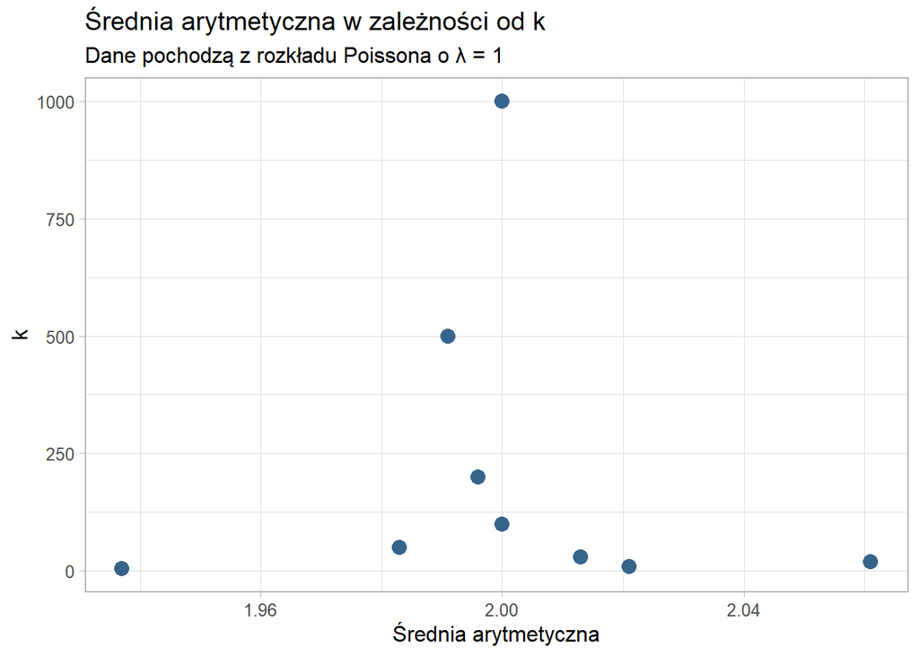

Różnica w rozproszeniu wartości średnich arytmetycznych w zależności od k nie jest widoczna.

*Tabela 2.6. Zestawienie średnich arytmetycznych w zależności od k* *dla danych z rozkładu Poissona z parametrem λ = 40 podniesionych do kwadratu*

| 5 | 10 | 20 | 30 | 50 | 100 | 200 | 500 | 1000 |
| --- | --- | --- | --- | --- | --- | --- | --- | --- |
| 1642.984 | 1646.321 | 1639.28 | 1640.852 | 1641.423 | 1639.453 | 1641.233 | 1639.051 | 1640.879 |

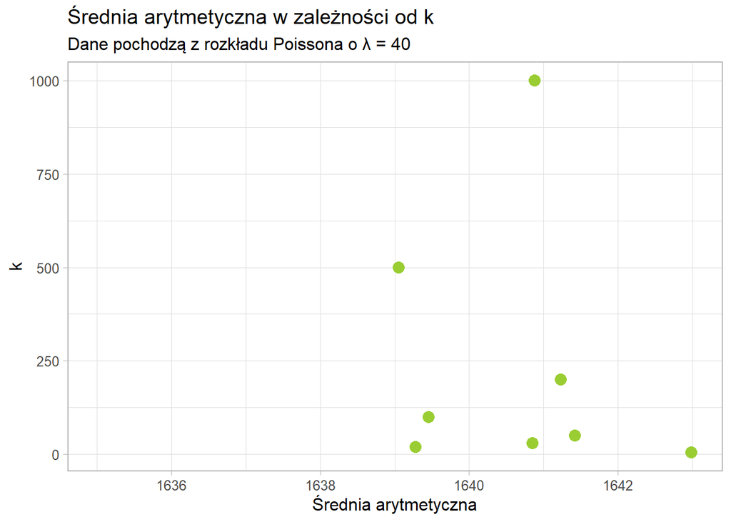

### Odchylenie standardowe

*Tabela 2.7. Zestawienie odchyleń standardowych w zależności od k* *dla danych z rozkładu Poissona z parametrem λ = 1 podniesionych do kwadratu*

| 5 | 10 | 20 | 30 | 50 | 100 | 200 | 500 | 1000 |
| --- | --- | --- | --- | --- | --- | --- | --- | --- |
| 1.531 | 1.024 | 0.788 | 0.621 | 0.458 | 0.34 | 0.226 | 0.145 | 0.103 |

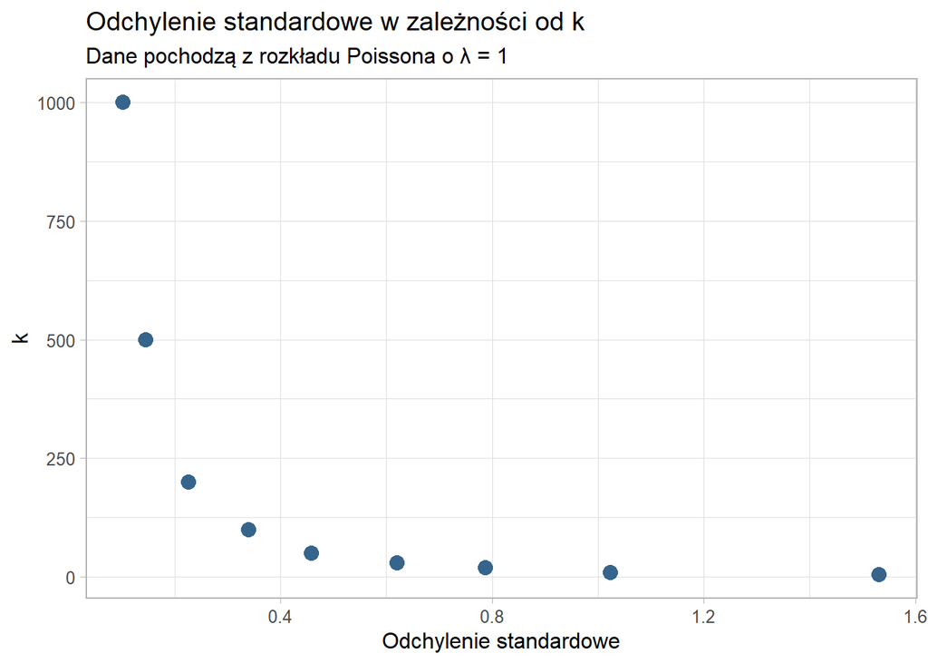

Powyższy wykres jednoznacznie wskazuje na zależność pomiędzy odchyleniem standardowym a wartością k: im mniejsze k, tym odchylenie standardowe wyższe.

*Tabela 2.8. Zestawienie odchyleń standardowych w zależności od k* *dla danych z rozkładu Poissona z parametrem λ = 40 podniesionych do kwadratu*

| 5 | 10 | 20 | 30 | 50 | 100 | 200 | 500 | 1000 |
| --- | --- | --- | --- | --- | --- | --- | --- | --- |
| 231.456 | 163.32 | 115.296 | 96.57 | 72.059 | 52.663 | 36.857 | 22.787 | 15.824 |

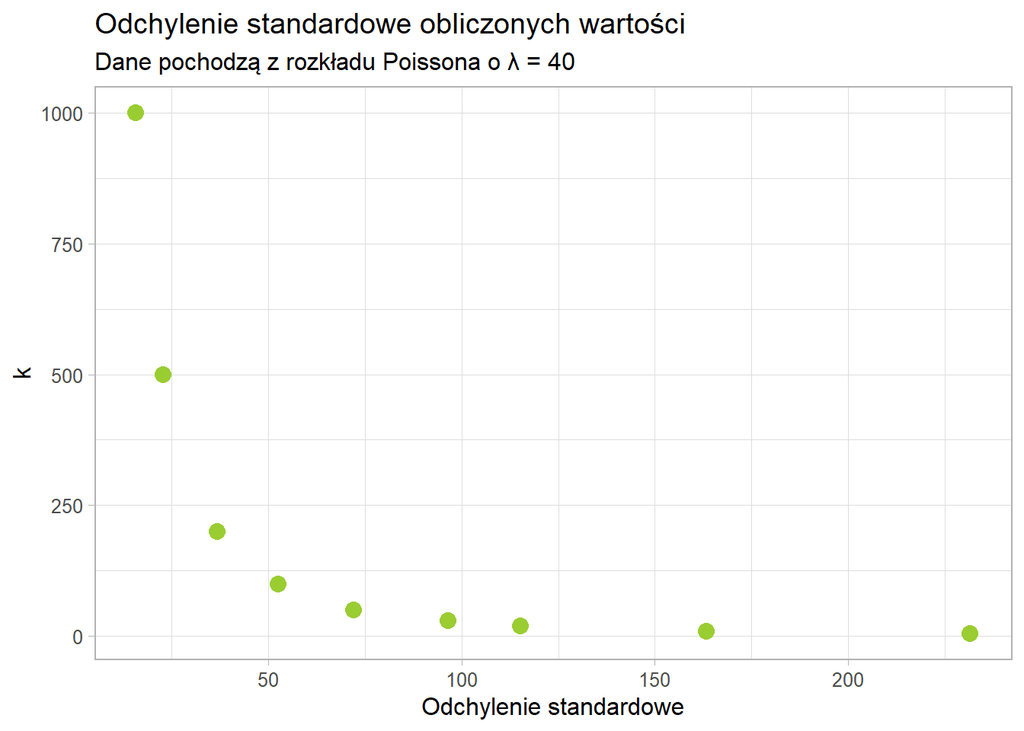

Na powyższym wykresie ponownie można dostrzec zależność: im większe k, tym mniejsze odchylenie standardowe.

### Skośność

*Tabela 2.9. Zestawienie współczynników skośności w zależności od k* *dla danych z rozkładu Poissona z parametrem λ = 1 podniesionych do kwadratu*

| 5 | 10 | 20 | 30 | 50 | 100 | 200 | 500 | 1000 |
| --- | --- | --- | --- | --- | --- | --- | --- | --- |
| 2.393 | 0.951 | 0.854 | 0.645 | 0.435 | 0.508 | 0.268 | 0.246 | 0.067 |

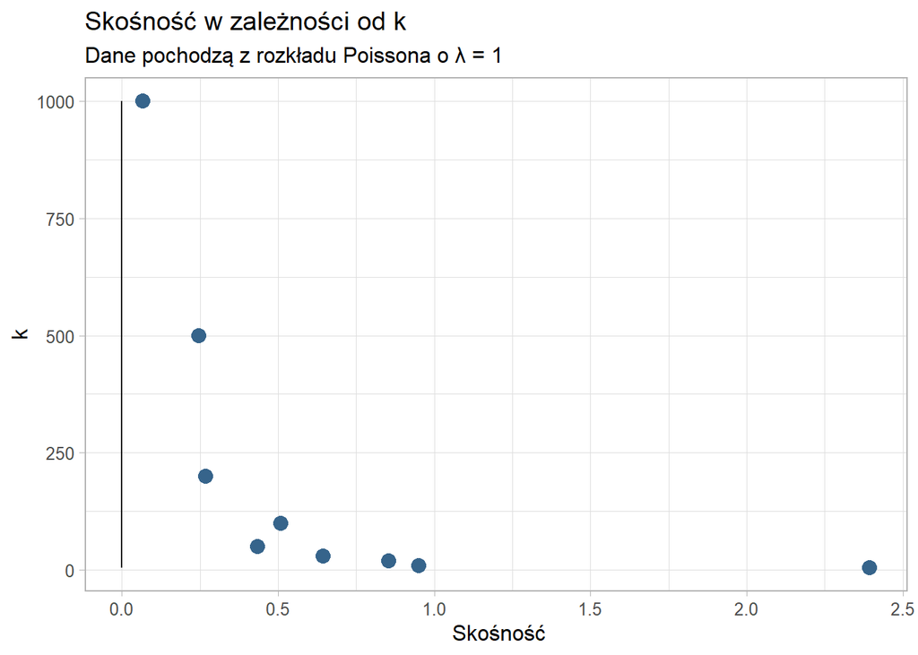

Jak można odczytać z powyższego wykresu dla każdego k wartości współczynnika asymetrii są większe od zera. Dodatni współczynnik asymetrii wskazuje na asymetrię prawostronną rozkładu. Oznacza to, że większość wartości jest mniejsza od średniej arytmetycznej. Ponadto można zauważyć, że skośność rozkładu jest zdecydowanie mniejsza dla dużych wartości k.

*Tabela 2.10. Zestawienie współczynników asymetrii w zależności od k* *dla danych z rozkładu Poissona z parametrem λ = 40 podniesionych do kwadratu*

| 5 | 10 | 20 | 30 | 50 | 100 | 200 | 500 | 1000 |
| --- | --- | --- | --- | --- | --- | --- | --- | --- |
| 0.398 | 0.308 | 0.217 | 0.213 | 0.084 | 0.017 | 0.034 | 0.116 | -0.04 |

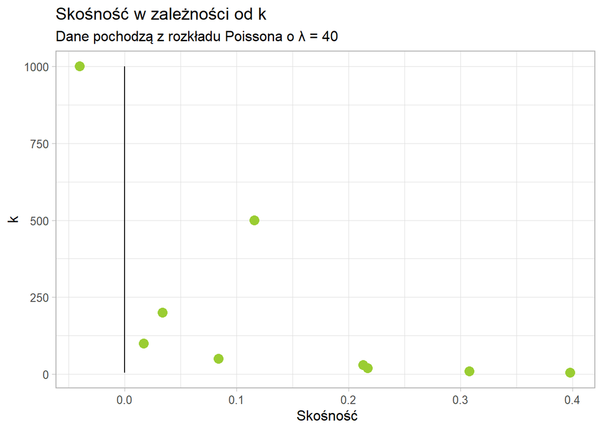

### Kurtoza

*Tabela 2.11. Zestawienie kurtozy w zależności od k* *dla danych z rozkładu Poissona z parametrem λ = 1 podniesionych do kwadratu*

| 5 | 10 | 20 | 30 | 50 | 100 | 200 | 500 | 1000 |
| --- | --- | --- | --- | --- | --- | --- | --- | --- |
| 15.442 | 4.08 | 3.831 | 3.522 | 3.323 | 3.422 | 2.875 | 3.235 | 2.868 |

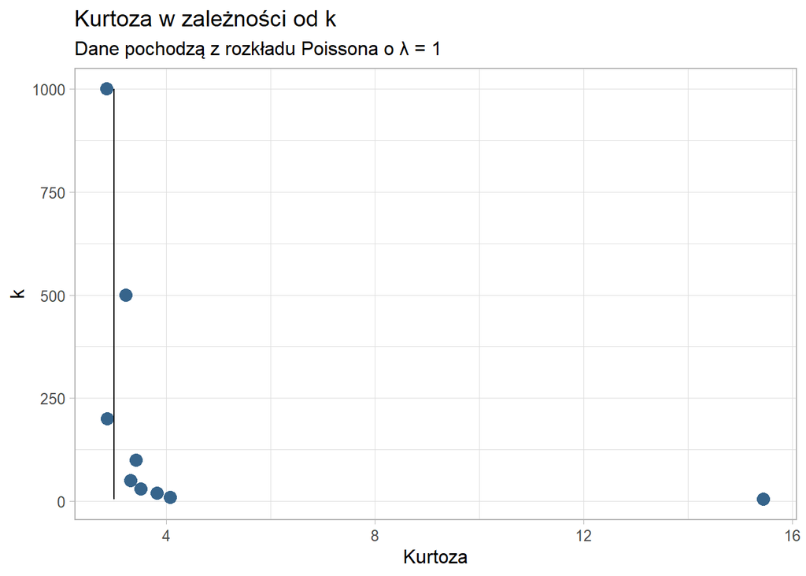

Ze względu na niską wartość współczynnika skośności możemy interpretować kurtozę. Zdecydowaną większość wartości charakteryzuje kurtoza większa od 3, co wskazuje na rozkłady leptokurtyczne.

*Tabela 2.12. Zestawienie kurtozy w zależności od k* *dla danych z rozkładu Poissona z parametrem λ = 40 podniesionych do kwadratu*

| 5 | 10 | 20 | 30 | 50 | 100 | 200 | 500 | 1000 |
| --- | --- | --- | --- | --- | --- | --- | --- | --- |
| 3.464 | 3.214 | 3.241 | 3.28 | 3.099 | 2.758 | 3.128 | 2.967 | 3.15 |

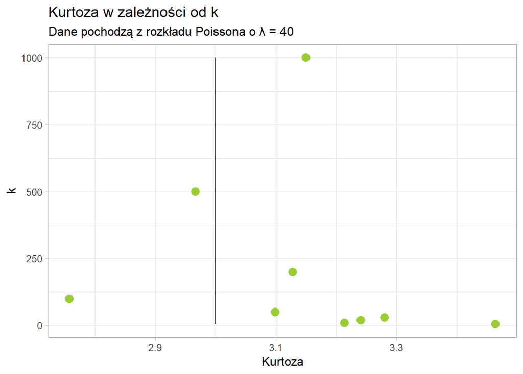

W tym przypadku kurtoza przyjmuje wartości zarówno mniejsze, jak i większe od 3, zatem występują tu rozkłady leptokurtyczne i platokurtyczne. Wyniki są bardzo zbliżone do wartości kurtozy dla rozkładu normalnego (K = 3). Oznacza to, że W miarę wzrostu parametru λ rozkład coraz bardziej zbliża się do rozkładu normalnego.